# Graphics Showing Diurnal Fluctuations in pH and Corrected CO<sub>2</sub>

Curtis C. Bohlen

- Introduction
- Load Libraries
- Load Data
  - Establish Folder References
  - Load OA Data
  - Calculate Diurnal Deviations
  - Generate Long Version of the Data
- Plot Daily pCO<sub>2</sub> Deviations
  - Plotting curves against scatter plots
- Combined Graphic
  - Corrected pCO2 Graph
  - pH Graph

# Introduction

This notebook seeks to document diurnal patterns in pH and temperature corrected pCO<sub>2</sub> based on equations in Takehashi et al. 2002. The approach is to look at 24 hour patterns in the deviations from daily averages. We expect these patterns do vary seasonally, so we analyze patterns by month, as a convenient way to look at annual variation.

> Takahashi, Taro & Sutherland, Stewart & Sweeney, Colm & Poisson, Alain & Metzl, Nicolas & Tilbrook, Bronte & Bates, Nicholas & Wanninkhof, Rik & Feely, Richard & Chris, Sabine & Olafsson, Jon & Nojiri, Yukihiro. (2002). Global sea-air CO2 flux based on climatological surface ocean pCO2, and seasonal biological and temperature effects. Deep Sea Research Part II: Topical Studies in Oceanography. 49. 1601-1622. 10.1016/S0967-0645(02)00003-6.

(See the “Data_Review_And_Filtering” R Notebook for details on why and how we calculated temperature-corrected pCO2 values.)

# Load Libraries

```r
library(tidyverse)
library(mgcv)
```

```r
library(CBEPgraphics)

load_cbep_fonts()
```

# Load Data

## Establish Folder References

```r
sibfldnm <- 'Derived_Data'
parent   <- dirname(getwd())
sibling  <- file.path(parent,sibfldnm)

fn    <- 'CascoBayOAData.csv'
fpath <- file.path(sibling,fn)
```

## Load OA Data

```r
all_data <- read_csv(fpath,
                     col_types = cols(dd = col_integer(),
                                      doy = col_integer(),
                                      hh = col_integer(),
                                      mm = col_integer(),
                                      yyyy = col_integer())) %>%
  select(c(13, 1:4, 14, 5:6, 8, 7 ,16, 9:12))
```

## Calculate Diurnal Deviations

We calculate hourly deviation from daily averages. This can be done using linear models and extracting residuals, but the code is cleaner using the Tidyverse. You could make the code shorter using mutate_at(), but being explicit here is clearer for readers. An alternative would be to calculate deviations from daily medians instead of daily averages. In this setting, it probably makes little differnce, but we did not explore that alternative.

```r
new_data <- all_data %>%
  mutate(month = factor(mm, levels = 1:12, labels=month.abb)) %>%
  group_by(yyyy, mm, dd) %>%

  # Calculate sample sizes for each daay.
  mutate(co2_n      = sum(! is.na(co2)),
         co2_corr_n = sum(! is.na(co2_corr)),
         ph_n       = sum(! is.na(ph))) %>%

  # Calculate centered but not scaled values, day by day.
  mutate(co2_res      = scale(co2, scale = FALSE),
         co2_corr_res = scale(co2_corr, scale = FALSE),
         ph_res       = scale(ph, scale = FALSE)) %>%
  ungroup(yyyy, mm, dd) %>%

  # Replace data from any days with less than 20 hours of data with NA
  mutate(co2_res      = ifelse(co2_n>=20, co2_res, NA),
         co2_corr_res = ifelse(co2_corr_n>=20, co2_corr_res, NA),
         ph_res       = ifelse(ph_n>=20, ph_res, NA)) %>%

  # Delete the daily sample size variable
  select(-contains("_n")) %>%
  mutate(Month = factor(mm, labels=month.abb))
```

## Generate Long Version of the Data

```r
long_data <- new_data %>% select(-c(7:15)) %>%  # Drop all raw observations; retain diurnal residuals
                                                # retain only pC02_corr f pH residuals
  pivot_longer(contains("_res"), names_to='metric') %>%
  mutate(metric= sub("_res", "", metric))       #simplify names
```

# Plot Daily pCO<sub>2</sub> Deviations

By using ggplot’s geom_smooth(), we can look graphically at GAM models by month. This is a convenient way to explore diurnal patterns by season.

It is worth noting that these models are likely to over-fit the data, because they do not take into account temporal autocorrelations. For graphical presentation, this is adequate, as detrending the time-series by day removed most of the autocorrelation structure that we do not wish to model directly. Large sample sizes also reduce the probability that over-fitting will matter.

Since GAM models use heuristics (based in part on the assumption of independent errors) to select an optimal level of smoothing, they are likely to try to fit some details that are an artifact of autocorrelation. While it is possible to fit GAMM models with a formal autocorrelation structure here, those models are slow, and raise other complications.

## Plotting curves against scatter plots

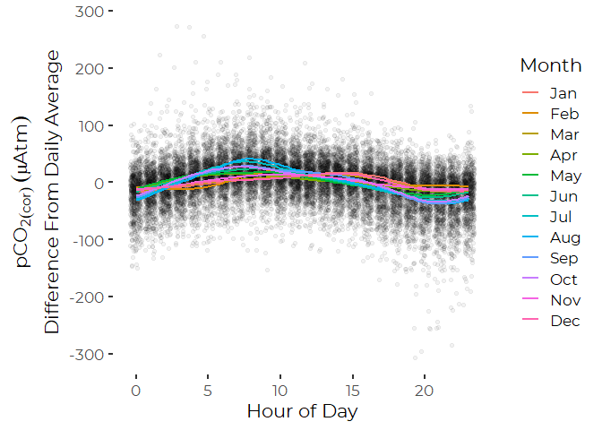

```r
plt <- ggplot(new_data, aes(hh, co2_corr_res)) + geom_jitter(alpha=0.05) +
  geom_smooth(aes(color = Month), method = gam,
              formula = y~s(x, bs='cc'), se=FALSE) +
  theme_cbep() +
  xlab('Hour of Day') +
  ylab(expression (atop(pCO[2*(cor)]~(mu*Atm), Difference~From~Daily~Average)))
plt
```

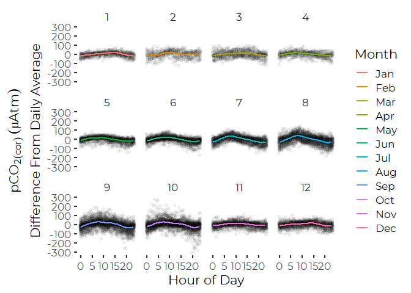

```r
plt + facet_wrap(~ mm)
```

# Combined Graphic

Lets combine those into faceted graphs.

Notice that the selection of the dimension of the periodic basis of the smooths in the GAM (signaled in k=6) is essentially selected here by eye to create a visual balance between simplicity and complexity. The default here probably over-fits, as described above. We explore the implied GAM (and related GAMM) further in the another R Notebook in the “Analysis” folder.

Unfortunately, ggplot does not make it easy to change the labels of facets. The key here is to alter the labels of the factor used to specify facets to include all the plotmath to generate the desired label

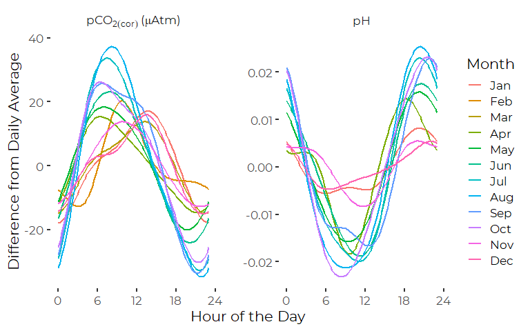

```r
labs <- c(expression(paste(pCO[2*(cor)], ' (', mu, 'Atm)')), 'pH')
names(labs) <- unique(long_data$metric)[2:3]

tmp <- long_data %>%
  filter( ! metric == 'co2') %>%
  mutate(metric = factor(metric, levels = names(labs), labels = labs))

plt <-
  ggplot(tmp, aes(hh,value, color = month)) +
  geom_smooth(aes(color = month), method = "gam",
              formula = y~s(x, bs='cc', k=6), se=FALSE) +

  theme_cbep() +
  theme(panel.spacing = unit(2, "lines")) +

  xlab('Hour of the Day') +
  ylab('Difference from Daily Average') +
  facet_wrap(~metric, nrow=1, scales='free_y',
                   labeller = label_parsed ) +
  scale_color_discrete(name = "Month") +
  scale_x_continuous(breaks = c(0,6,12,18,24)) #+
  #ggtitle('Daily Fluctuations')
plt
```

```r
ggsave('dailyco2andphbymonth.pdf', device = cairo_pdf, width = 8, height = 5)
ggsave('dailyco2andphbymonth.png', type = 'cairo', width = 8, height = 5)
```

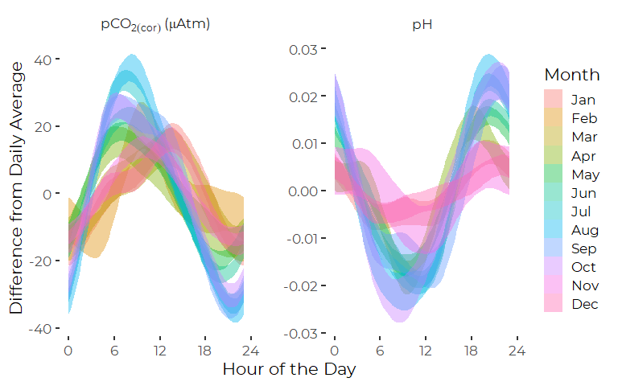

```r
labs <- c(expression(paste(pCO[2*(cor)], ' (', mu, 'Atm)')), 'pH')
names(labs) <- unique(long_data$metric)[2:3]

tmp <- long_data %>%
  filter( ! metric == 'co2') %>%
  mutate(metric = factor(metric, levels = names(labs), labels = labs))

plt <-
  ggplot(tmp, aes(hh,value, color = month)) +
  geom_smooth(aes(color = month, fill=month), method = "gam",
              formula = y~s(x, bs='cc', k=6), se=TRUE,
             # alpha = 0.2,
              linetype = 0
             ) +

  theme_cbep() +
  theme(panel.spacing = unit(2, "lines")) +

  xlab('Hour of the Day') +
  ylab('Difference from Daily Average') +
  facet_wrap(~metric, nrow=1, scales='free_y',
                   labeller = label_parsed ) +
  scale_color_discrete(name = "Month") +
  scale_fill_discrete(name = "Month") +
  scale_x_continuous(breaks = c(0,6,12,18,24)) #+
  #ggtitle('Daily Fluctuations')
plt
```

```r
ggsave('dailyco2andphbymontherror.pdf', device = cairo_pdf, width = 8, height = 5)
ggsave('dailyco2andphbymontherror.png', type = 'cairo', width = 8, height = 5)
```

Daily fluctuations are at their peak in the late summer and early fall, with highest pCO<sub>2</sub> observed in the morning, soon after sunrise. Lowest values are a few hours after sunset. By mid-winter, the fluctuations are smaller, with peaks later in the day, around sunset, which suggests CO2 is being released all day long, and reabsorbed at night, which I don’t quite understand. Also note that timing or pCO<sub>2</sub> and pH fluctuations don’t match consistently across months.

## Corrected pCO2 Graph

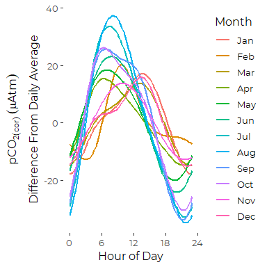

```r
plt <- new_data %>%
  ggplot(aes(hh,co2_corr_res, color = month)) +
  geom_smooth(aes(color=month), method = "gam",
              formula = y~s(x, bs='cc', k=6), se=FALSE, lwd=0.75) +
  # annotate(geom = "text", label = expression(atop("Temperature", "Corrected"~pCO[2])),
  #          x = 24, y = 30,
  #          color = "black", hjust=1, size = 4) +
  theme_cbep(base_size = 12) +
  xlab('Hour of Day') +
  ylab(expression (atop(pCO[2*(cor)]~(mu*Atm), Difference~From~Daily~Average))) +
  scale_color_discrete(name = "Month") +
  theme(legend.key.width = unit(0.25,"in"),
        legend.text      = element_text(size = 10)
        ) +
  scale_x_continuous(breaks = c(0,6,12,18,24)) #+
  #ggtitle(expression(Daily~pCO[2]))
plt
```

```r
ggsave('dailyCO2bymonth.pdf', device=cairo_pdf, width = 4, height = 4)
ggsave('dailyCO2bymonth.png', type='cairo', width = 4, height = 4)
```

## pH Graph

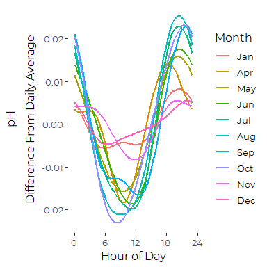

```r
plt <- new_data %>%
  ggplot(aes(hh,ph_res, color = month)) +
  geom_smooth(aes(color=month), method = "gam",
              formula = y~s(x, bs='cc', k=6), se=FALSE) +
  theme_cbep(base_size = 12) +
  theme(legend.key.width = unit(0.25,"in"),
        legend.text      = element_text(size = 10)
        ) +
  xlab('Hour of Day') +
  ylab(expression (atop(pH, Difference~From~Daily~Average))) +
  scale_color_discrete(name = "Month") +
  scale_linetype_discrete(name = "Month") +
  theme(legend.key.width=unit(0.25,"in")) +
  scale_x_continuous(breaks = c(0,6,12,18,24)) #+
  #ggtitle(expression(Daily~pH))
plt
```

```r
ggsave('dailyphbymonth.pdf', device=cairo_pdf, width = 4, height = 4)
ggsave('dailyphbymonth.png', type='cairo', width = 4, height = 4)
```